# Evolution Prac 2 — Access genetic data from GenBank

Dr James B Dorey and Dr Damien Esquerré, University of Wollongong

Version 2026-08-03; practical 2026-08-07

Abstract

R is a very useful programming language that’s open access and widely used in science. We don’t expect you to become a master by the end of this topic or to understand everything that you’re doing right now. But, by helping you get started and giving you robust example code we hope to enable you to succeed using R in the future, should you chose to pick it up more consistently. Here, we will use it as an *example* of how you can run genetic/phylogenetic analyses on a single platform. But note, others do exist.  
**Be certain to save your R script from this week to help you next week!**

**THIS IS A DEMONSTRATOR ONLY VERSION**

**Attention:**  
**Once you have completed all of the questions** and **shown your demonstrator or Lecturer** the answers and the outputs, you may leave. Or, feel free to hang around, play, or help your classmates.

# 1 Script preparation

## 1.1 Working directory

To start with, let’s set up a working directory in a place that makes sense. We will use this working directory to, preferably, keep ALL of the data and scripts associated with this project. This is because, if we were to start putting files and scripts all over the computer, we increase the chances of losing them as we change file names and paths and, if we want to share the whole project, we can share everything by compressing and sharing one folder. **Save this folder for next week!**

```r
  # Set the RootPath to EPrac2 folder
RootPath <- "YourFolderPathHere"
  # You can then set this as the project's working directory.
  # This is where R will first look to find
  # or save data as a default
setwd(RootPath)
```

## 1.2 Install packages

R is a programming language which has a [*base*](https://stat.ethz.ch/R-manual/R-devel/library/base/html/00Index.html) and several default packages. But, because R is an open-source programming language, it currently has *20,853* packages available on [“CRAN”](https://cran.r-project.org/web/packages/); the official R package repository. Additional reliable R packages can be sourced from [bioconductor](https://www.bioconductor.org/packages/release/BiocViews.html#___Software) (*2,300* packages for working with biological data) and countless others on GitHub.

This is all to say that the possibilities of analyses in R are nearly endless, free, open source, and widely used. This makes R an incredibly powerful language to learn for your education, research, and future career.

To start out, we will need to install some basic packages. In particular, we will install packages in the *tidyverse* which have benefits over R’s *base* packages in that they tend to be quicker and, more importantly, much easier to code with and understand.

You’ll notice that we are actually defining an R object as a simple character vector called “packageList” and then feeding it into the *base* R `install.packages()` function.

```r
packageList <- c(
    # Tidyverse packages:
  "dplyr",            #  For data management and table manipulation
  "magrittr"          #  to use tidy pipes; %>%
)

# List the new (not installed) packages and then if there are any, install them.
install.packages(pkgs = c(packageList),
              rebuild = FALSE,
              repos = "http://cran.us.r-project.org")
```

While you’re here, why don’t you run just the below word in your console and see what comes up. You can then also run that same object in the *base* R `class()` function to see what type it is.

```r
packageList
```

```
#> [1] "dplyr"    "magrittr"
```

```r
class(packageList)
```

```
#> [1] "character"
```

> **Q1:** How does your input for “packageList” vary from what comes out when you run it in the R console?

**The input uses the ‘combine’ function, ‘c’ and commas between. The output is simply the text returned as a list.**

> **Q2:** What is the class of “packageList”?

**The class is ‘character’.**

## 1.3 Load packages

Even though we have installed the packages, we actually need to explicitly call each package using the `library()` function. This tells R which packages it should use and can solve issues of one function being called by multiple packages.

So, let’s go ahead and load in the packages that we just installed.

```r
# Load all packages from the list specified above
lapply(c(packageList),
       library, character.only = TRUE)
```

```
#> [[1]]
#>  [1] "dplyr"      "kableExtra" "styler"     "formatR"
#>  [5] "rmarkdown"  "stats"      "graphics"   "grDevices"
#>  [9] "utils"      "datasets"   "methods"    "base"
#>
#> [[2]]
#>  [1] "magrittr"   "dplyr"      "kableExtra" "styler"
#>  [5] "formatR"    "rmarkdown"  "stats"      "graphics"
#>  [9] "grDevices"  "utils"      "datasets"   "methods"
#> [13] "base"
```

I prefer to go one step further, which removes the issue almost entirely, and is useful when going over your scripts and making it easy to find errors and understand what’s happening. You can, at each function, explicitly call the package using two colons — `package**::**function()`. For example:

```r
  # We can explicitly call the base package's "library" function.
  # However, I tend to not do this with the base and default packages.
base::library(dplyr)
```

Now, that’s probably enough of an introduction to R. We can work through more of that at a later time and in the course of this topic. Now, let’s get onto the subject at hand… Harvesting genetic data.

# 2 Accessing GenBank over a browser

There are several places online to download published genetic data, but for life sciences, [GenBank](https://www.ncbi.nlm.nih.gov/genbank/) is probably the major host. But, it is not the sole repository. Especially for the increasing amounts of next generation sequencing datasets, authors are hosting data on generalist repositories like [FigShare](https://figshare.com).

We are *also* going to access genetic data from GenBank using R. However, I think its still very much worthwhile taking an initial look on the website itself and this is how I would personally access these data in the first instance. Navigate to the [GenBank](https://www.ncbi.nlm.nih.gov) homepage now. At the top of the page, there is a search bar, there search “**All Databases**” for one of Darwin’s finches, “*Geospiza conirostris*” (**Fig. 1**).

[figure not shown]

The GenBank search bar.

This search should return something like the below (**Fig. 2**). Now, there’s quite a lot to see there and GenBank has broken it down into the literature sources and citations (which is very helpful!). It also provides data in the form of genomes from various sources, genes, genetic data associated with health issues (“*Clinical*”), and proteins. Basically, GenBank is seeking to be able to host and share a whole bunch of molecular data with anyone who wants to use it. Great open science! **Just remember, when you use these data you must cite the original source!** Good thing that GenBank gives the citation to you.

## 2.1 Searching a taxon

Under **Genomes**, let’s click on **Nucleotide**. Here you will see a whole bunch of single gene region extracts from finches of this species, information about the gene that has been sequenced (e.g., mitochondrial control region, cytochrome b, class IIB antigen gene, cytochrome b (cytb), and other stupid gene names…), and information about those extracts. Underneath there is more information to help you decide what you might like to look at, such as the number of sequences provided and the type of study.

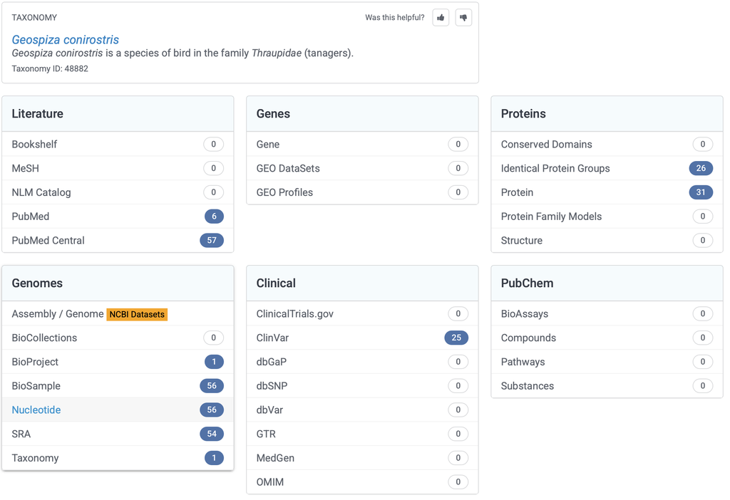

The search results from GenBank for the finch, “*Geospiza conirostris*”.

Let us **view 200 results per page (up the top)** and then find and click on “Geospiza conirostris strain DR81*111 mitochondrial control region, partial sequence” and look a little closer.

> **Q3:** There are sequences from how many individuals in this dataset??

**There are data from only one specimen.**

> **Q4:** What is the *title* and *journal* of the study that produced these genes and shared them on GenBank?

**The title is ‘Phylogeny of Darwin’s finches as revealed by mtDNA sequences’ AND the journal ‘Proc. Natl. Acad. Sci. U.S.A. — PNAS’**

> **Q5:** What are the first 10 basepairs for the sequence? *HINT: have a look down the bottom of the page.*

**The first ten basepairs are ‘atagccaacg’**

> **Q6:** On the page, can you find and download the entire sequence in a **FASTA** format? *HINT: search the page for “FASTA” and click on that link; on that page at the top right use the “Send to:” drop down to select “File” and then click “Create File”.*

> **Q7:** What does the fasta file look like and what information does it contain?

**The file, called ‘sequence.fasta’ contains the individuals’ name and potentially other information after a greater than symbol, ‘>’. ‘>AY064447.1 Loxigilla noctis isolate LonoC62i3 MHC class IIB antigen gene, exon 2 and partial cds’. And then the sequence itself starting on a new line ‘>AF109041.1 Geospiza conirostris strain DR81 111 mitochondrial control region, partial sequence’ ‘ATAGCCAACGTCATACGTCATGCCCCTCCACCAAAAGCCCAAACATTATCTCCAAAACGG…’**

Fasta files are one of the most commonly used formats for genetic data. They are nice and simple files that are essentially just plain text that store two data types (**Q7**). Their simplicity makes them powerful and easy to understand.

## 2.2 Searching a group

Now, let’s make a more useful search. Let us try and find the data that’s available for all of Darwin’s finches in the genera *Geospiza*, *Cactospiza*, *Camarhynchus*, and *Certhidea*.

Go back to the [GenbBank](https://www.ncbi.nlm.nih.gov) homepage and instead of searching “**All Databases**”, search “**Nucleotide**” and click “**Search**” with the text bar empty and, on the following page, click “**Advanced**”. Here, we can start to build an advanced query. > 1. In the first field, enter “cytb” which is the mitochondrial gene “*cytochrome b*”; a very commonly used gene for shallow (~recent divergences) inter-species phylogenetic analyses. Choose the drop-down as “**Gene Name**” and not “**All Fields**”.

> 2. In the next four fields put the four bird genera names and choose the drop-down as “**Organism**”
> 3. In the “**AND**” drop-downs, choose “**OR**” and click “**Search**” (**Fig. 3**)

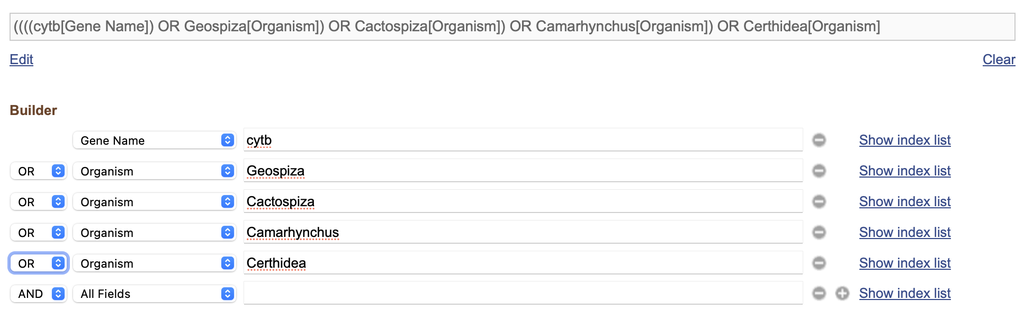

A GenBank advanced search. Note, that as you enter names into the Builder, a text version of your search query is built directly above!

> 4. Because we have chosen all “**OR**”s, we actually have cytB genes for any species at all! Oops! However, we can fix this and make a much better search with this In the search bar at the top, you can see that our search has been turned into a text query!

> “((((cytb[Gene Name]) OR Geospiza[Organism]) OR Cactospiza[Organism]) OR Camarhynchus[Organism]) OR Certhidea[Organism]”

Here you can see that our query is bounded by a bunch of confusing brackets. They are specifying the relationships between each query, but what we want is to find all cytB genes for any (**OR**) of the four genera, so we can enclose the gene name and then all of the genera, separated by an “**AND**” to specify this. Go ahead and make this change or paste the below query into the search bar.

> “**(**cytB[Gene Name]**) AND (**Geospiza[Organism] OR Cactospiza[Organism] OR Camarhynchus[Organism] OR Certhidea[Organism]**)**”

Now, you’ll see that there are some crazy genetic materials in there. Previously this has included genomic data (genes from in the cell nucleus). On the left-hand side there’s a filter that you can choose called “**Mitochondrion**” (search for it on the page if you need). Click on that and you’ll see that what’s mostly left are a bunch of 800 to 1,120 basepair sequences. But, there are also some much long full mitogenomes (>16,000 bp) and sequences of different lengths (probably differing due to the sequencing and filtering methods used in their production). You may also note that “*AND mitochondrion[filter]*” was also added to the search query.

> Our final search term becomes “(cytb[Gene Name]) AND (Geospiza[Organism]) OR Camarhynchus[Organism] OR Certhidea[Organism]) **AND (mitochondrion[filter])**”Give that a search and note the number of sequences.

## 2.3 Download sequence data from the browser

From this point, you might go through these sequences and try to find one for each species you want to include, or a subset of those species. You might sort these sequences by length (**Fig. 4**) and then look for the longest sequence of each species as you scroll down the page.

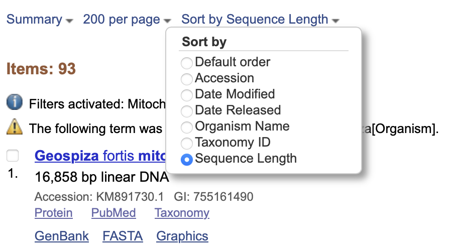

Sort GenBank results by length also note that’s i’ve chosen to display 200 records per page.

Why don’t you take a few moments to try and find the longest sequences for all of the species that have cytB data on GenBank? **Hint**: there are 14 species that I can see cytB for: *Geospiza magnirostris*, *Geospiza fortis*, *Camarhynchus heliobates*, *Geospiza difficilis*, *Geospiza conirostris*, *Certhidea fusca*, *Certhidea olivacea*, *Camarhynchus psittacula*, *Camarhynchus parvulus*, *Camarhynchus pauper*, *Geospiza fuliginosa*, *Geospiza scandens*, *Geospiza septentrionalis*, and *Camarhynchus pallidus*.

You could download each as a fasta file and then copy them together in a text editor, or just click on “FASTA” for each sequence and copy the fasta text into a text file (**Fig. 5**). **Note**: for mac users [**BBEdit**](https://apps.apple.com/us/app/bbedit/id404009241?mt=12) is a fantastic and free text editor (**Fig. 6**).

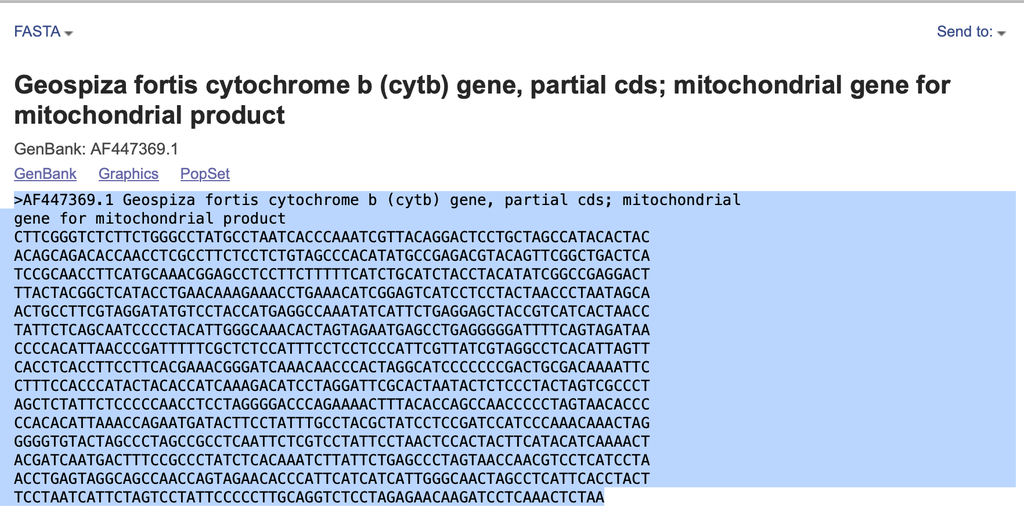

Copy the two lines of each fasta and paste it into a text editor (next figure).

[figure not shown]

Save this file with an informative name in your R working directory and with the file suffix “.fasta”. Maybe something like *darwinFinches_cytB.fasta* — we will skip this part right now in favor of showing you, very quickly, how to accomplish this in R. However, reading the fasta into R is really simple using the **ape** package (see the example line of code below and the next section).

```
DarwinFinches_cytB <- ape::read.FASTA("darwinFinches_cytB.fasta")
```

**Warning:** Sometimes your computer will try to save this as *darwinFinches_cytB.fasta**.txt***. You either need to remove that or include it when you read into ape.